# Economic Analysis of Electric Vehicle Charging Price

Marco Ruffinelli-Ojeda

San Francisco State University

2022

## Table of Contents

1. Introduction
2. Literature Review
3. Research Question & Addition to Literature
4. Limitations & Constraints
5. Description of Variables
6. Models
7. Results
8. Conclusion & Further Research

## 1. Introduction

In the last decade the infrastructure for electric vehicle (EV) charging experienced enormous growth. Yet, there still exists a scarcity of EV infrastructure.

Most EVs are charged at homes–EV owners find it inconvenient to go to commercial charging stations, often due to a lack of charger availability.

This research seeks to understand how the cost of EV charging varies around the United States.

**We find significant and substantial effects for geographic region, facility type, charging network, and for measures of variable cost (electricity), supply (# of charging cables), and demand (vehicle miles traveled).**

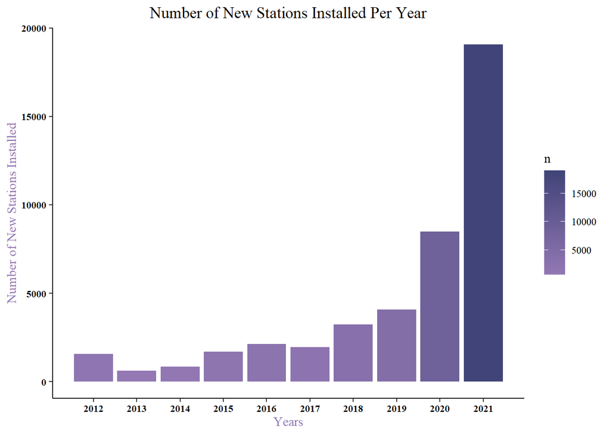

**Here's why you should care.**

**I. Electric Vehicles represent the future of driving.**

We are entering a tipping Point: 5%-10% of New automotive sales. This will be 25% in 3-5 years.

Auto Manufacturers are aligning their infrastructure to develop more EVs.

**II. Climate Change**

Transportation 14% of Global Emissions (EPA, 2010). Driving 45% of Transportation Emissions (IEA, 2018). 6% of Total Global Emissions comes from automotives. Constitutes to 15% of total U.S. global emissions.

**III. Other Motivations**

EV's promote cleaner air, less pollutant related deaths

**Gas Prices Are Too Damn High!**

## 2. Literature Review

- [*Does green investment improve energy firm performance?*](https://doi.org/10.1016/j.enpol.2021.112252)
  - Findings: Green investment can significantly improve financial performance in the long run, and improves short-term environmental performance.
  - Notable Data: Paper selects energy listed firms in China from 2008 to 2017 as the research sample, and sources financial data as well as firm social governance report.
- [*Electric vehicles revisited: a review of factors that affect adoption*](https://doi.org/10.1080/01441647.2016.1217282)
  - Findings:EV adoption will be limited without closing the gap between EV and internal combustion engine (ICE) vehicle costs.
  - Notable Data: Both panel & cross sectional data of HEV (Hybrid EV), “cross-country” data on charging infrastructure.
- [*Consumer behavioral adaption in EV fast charging through pricing*](https://doi.org/10.1016/j.enpol.2017.05.051)
  - Findings: Fast charging stations are often occupied for >30 minutes. A flat-fee incentives the user to spend longer times at charging stations.
  - Notable Data: Real world, time-series data.

## 3. Research Question & Addition to Literature

The origin of our research can be traced back to the insightful experiences and observations of Ruffinelli-Ojeda in the realm of electric vehicle (EV) mobility. Ruffinelli-Ojeda's firsthand understanding of the dynamics and mechanisms at play motivated us to delve deeper and ask more nuanced questions. One such question, which was inspired by a Chief Financial Officer's curiosity about the government's role, involves the effects of policy shifts on the EV industry. Specifically, we aim to understand how changes in government subsidies could potentially influence EV charging prices.

Beyond this, our research also seeks to delve into the broader factors that may impact EV charging prices, assessing their respective degrees of influence. This pursuit requires us to engage with a variety of factors including market trends, technological advances, infrastructural capabilities, and regulatory frameworks, among others. Our goal is not only to identify these factors but also to quantify their impact and establish a comprehensive understanding of the interplay among them.

Another important facet of our study focuses on developing empirical measures to effectively gauge supply and demand for EV charging. To achieve this, we propose to leverage public data and construct robust models that could capture the market dynamics accurately.

This research serves as an important addition to the existing literature by extending our understanding of consumer behavior in the EV market. It seeks to contribute a new dimension by analyzing the impact of network effects on EV charging, an aspect previously overlooked in scholarly discourse. Through this comprehensive approach, our research aims to broaden the scholarly landscape and offer fresh perspectives on the dynamics of the EV charging market.

## 4. Limitations & Constraints

**Sources**

While conducting our research, we faced several limitations and constraints, primarily pertaining to our data sources and their quality. Our sources included numerous reputable agencies and organizations, such as the U.S. Government, the Department of Energy (DoE) with its sub-agencies like the Office of Energy Efficiency and Renewable Energy (EERE), the Alternative Fuels Data Center (AFDC), and the Energy Information Administration (EIA).

We also sourced data from the Department of Transportation (DoT), including the Bureau of Transportation Statistics (BTS) and Federal Highway Administration (FHA), the Census Bureau, the Environmental Protection Agency (EPA), and several commercial entities like EV Go, Charge Point, and Plug Share. Additionally, the Clean Cities Coalition, the International Energy Agency, the Argonne National Lab's Center for Transportation Research, and AAA also provided valuable data for our research.

**Quality**

Despite these varied sources, we encountered some challenges related to the quality of the data. For instance, the AFDC price data had inherent limitations owing to its nature, and there was a notable lack of granularity in non-station geographic data. Our budget constraints prevented us from acquiring microgeographic data tools, which could have otherwise enhanced the detail and depth of our analysis. Furthermore, the data collected were essentially snapshots taken at specific points in time and did not provide a continuous, time-series perspective.

Another significant constraint was the minimal variation observed in the dependent variable prices, which was coupled with large variations across different states. This discrepancy complicated our analyses and limited the extent of the conclusions we could draw. Despite these limitations, we endeavored to provide the most comprehensive insights possible with the resources at our disposal.

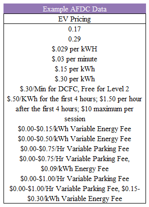

## 5. Description of Variables

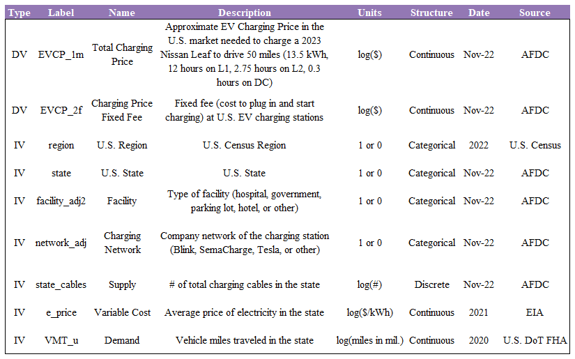

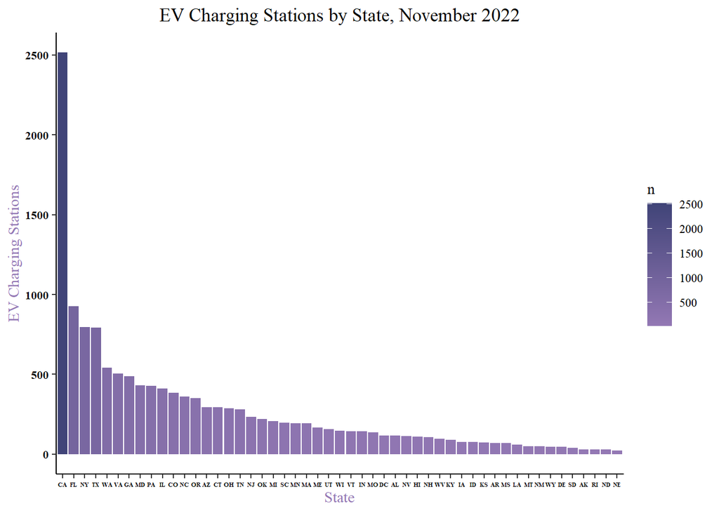

## 6. Models

- Model 1:
  $$\scriptsize
  log(TotalChargingPrice) = U.S. Region + Facility + Charging Network +
  log(Supply) + log(VariableCost) + log(Demand)$$
- Model 2:
  $$\scriptsize
  log(ChargingPriceFixedFee) = U.S. State + Facility + Charging Network +
  log(Supply) + log(VariableCost) + log(Demand)$$

## 7. Results

|  | *Dependent variable:* |  |
| --- | --- | --- |
|  | (1) | (2) |
| regionMidwest | 0.014 |  |
|  | (0.034) |  |
| regionNortheast | -0.053** |  |
|  | (0.024) |  |
| regionSouth | 0.020 |  |
|  | (0.021) |  |
| FL |  | -0.422 |
|  |  | (0.285) |
| TX |  | 0.096 |
|  |  | (0.325) |
| WA |  | 0.500** |
|  |  | (0.207) |
| facility_adj2government | -0.066 | -0.711*** |
|  | (0.081) | (0.223) |
| facility_adj2hotel | 0.034 | 0.732*** |
|  | (0.045) | (0.233) |
| facility_adj2parking | -0.147** | -0.259 |
|  | (0.069) | (0.234) |
| facility_adj2retail | 0.062*** | -0.382*** |
|  | (0.014) | (0.096) |
| network_adjBlink | 0.399*** | 1.217*** |
|  | (0.033) | (0.308) |
| network_adjSemaCharge | 0.059 |  |
|  | (0.037) |  |
| network_adjTesla | -0.275*** |  |
|  | (0.031) |  |
| log(state_cables) | -0.099*** | -0.755*** |
|  | (0.019) | (0.160) |
| log(e_price) | 0.156*** | 1.780*** |
|  | (0.034) | (0.322) |
| log(VMT_u) | 0.082*** | 0.768*** |
|  | (0.017) | (0.171) |
| Constant | 1.763*** | 2.186 |
|  | (0.133) | (1.609) |
| *Note:* | *p<0.1; **p<0.05;*** p<0.01 |  |

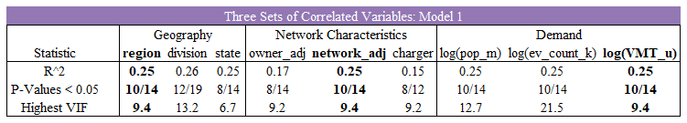

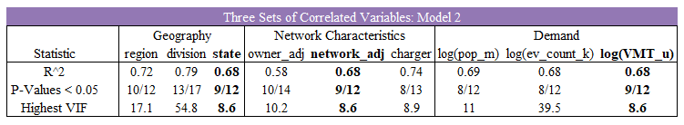

Our findings reveal an interesting dichotomy in the electric vehicle (EV) charging landscape. Specifically, we observed that the pricing strategy of Blink, a leading EV charging provider, is comparatively expensive, while Tesla's strategy, on the other hand, appears to be more cost-efficient. This could be attributed to Tesla's business model, which aims to incentivize consumers to buy their electric vehicles by keeping the charging costs relatively low. This acts as a key differentiator in the marketplace and could significantly sway the purchasing decision of potential EV buyers.

However, we must underline that while analyzing this complex system, issues such as multicollinearity and heteroskedasticity must be closely monitored. Multicollinearity, which is the correlation among independent variables, can distort the model's estimations. Similarly, heteroskedasticity, characterized by a situation where the variability of the error terms is unequal across different levels of the explanatory variables, can complicate the interpretation of results. Therefore, rigorous statistical checks are crucial to maintain the integrity of the research findings. Below are the plots which further detail this.

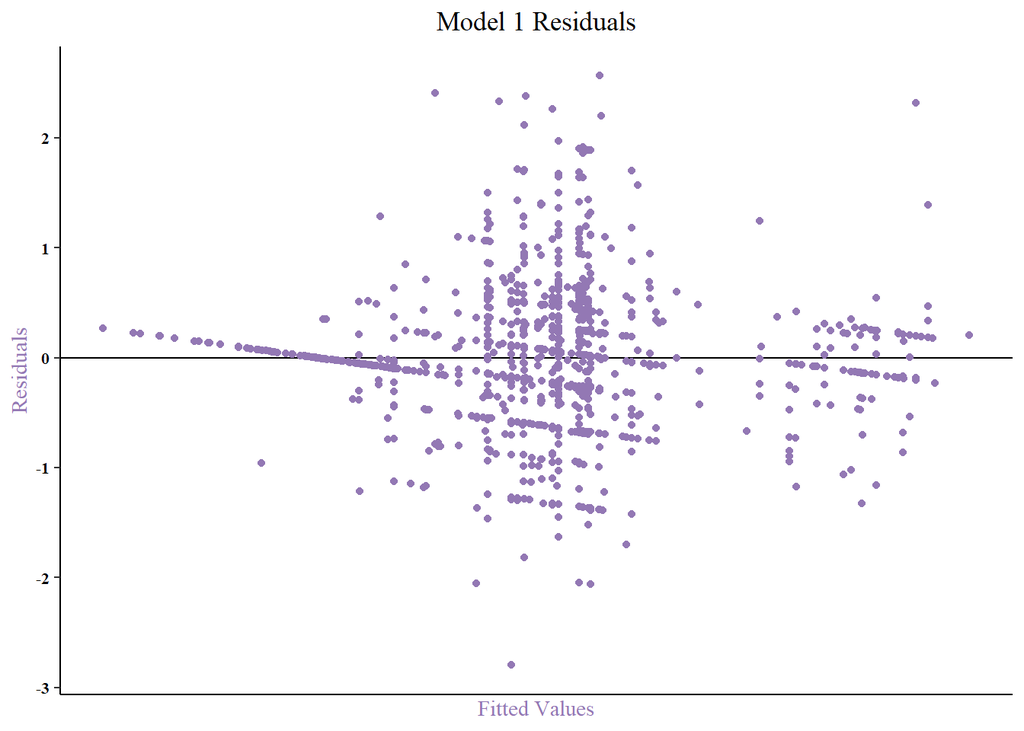

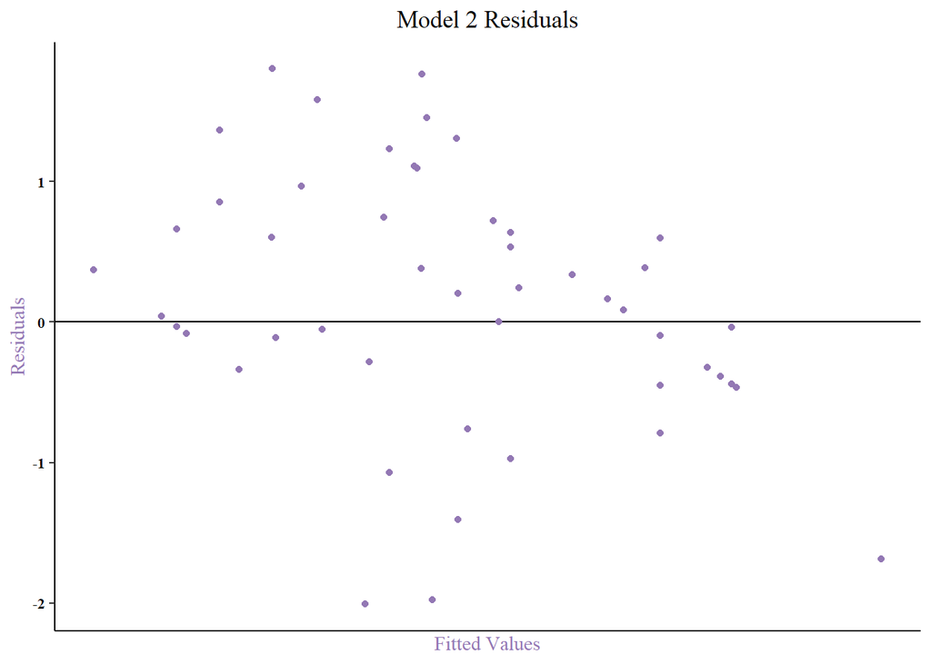

[figure not shown]

## 8. Conclusion & Further Research

In conclusion, our research offers valuable insights into the current landscape of the electric vehicle (EV) charging market. As we look towards the future, the potential growth of the EV market and its corresponding charging infrastructure is promising. Several critical factors will drive this growth, including technological advancements, changing consumer preferences, and supportive government policies.

One specific area we suggest for further research is the effect of government subsidies on charging prices. As government policy is an influential factor in the EV market, a detailed understanding of its impact could offer valuable insights for both policy makers and market participants. This includes investigating how changes in subsidies could impact the competitive landscape and influence the pricing strategies of charging service providers.

A comprehensive cost-benefit analysis of EV policies could also prove beneficial, particularly in assessing the existence and scale of positive externalities. This could help quantify the societal benefits of adopting EVs and, by extension, influence the scale and design of future policies.

Another interesting area for further research could be the examination of two-part tariffs in the context of EV charging. This refers to a pricing strategy where consumers pay a fixed fee for access and a variable fee based on usage. Understanding how this approach could be applied to EV charging may offer new opportunities for market differentiation and consumer engagement.

Lastly, a deeper dive into the network effects and the practice of tying could provide valuable insights. Network effects refer to the phenomenon where the value of a product or service increases with the number of users, while tying is a strategy where a company sells two products together. Given the growth and dynamism of the EV market, these areas could offer fascinating avenues for future exploration.